# Statystyki NBA sezon 21-22 oraz ikony ligi NBA

Author

Bartłomiej Fijołek

Published

January 14, 2023

**Czym jest NBA?**

**National Basketball Association** (skrót ang. NBA) amerykańsko-kanadyjska liga koszykarska, o charakterze profesjonalnym. Tworzy ją 30 zespołów, w tym: 29 z Stanów Zjednoczonych i jeden z Kanady. Liga jest aktywnym członkiem USA Basketball, oddziału Fédération Internationale de Basketball na terytorium Stanów Zjednoczonych. Jej komisarzem od 1 lutego 2014 roku jest **Adam Silver**. NBA jest jedną z pięciu największych północnoamerykańskich zawodowych lig sportowych (oprócz niej NFL, NHL, MLS i MLB). Gracze NBA są najlepiej opłacanymi sportowcami świata (w średniej rocznych zarobków). (Patrz więcej informacji “National Basketball Association” (2022) ) W historii NBA najwięcej tytułów zdobyły: Boston Celtics — 16, Los Angeles Lakers — 15 i Chicago Bulls — 6; do najlepszych zawodników NBA należeli m.in.: K. Abdul-Jabbar, L. Bird, W. Chamberlain, B. Cousy, **J. Erving**, J. Havlicek, E. „Magic” Johnson, M. Jordan, M. Malone, G. Mikan, S. O’Neal, B. Pettit, O. Robertson, **B. Russell**, J. West (poniżej aktualne logo ligi).

[figure not shown]

# Podsumowanie sezonu 21-22 w NBA

Sezon regularny w amerykańskiej koszykówce rozpoczął się 19 października 2021 roku, a zakończył 10 kwietnia 2022 roku. Następnie została rozegrana faza play-off, która potrwała do 16 czerwca 2022 roku. Sezon regularny składa się z **82** meczów, każdy z meczy jest podzielony na 4 kwarty po 12 minut i jeśli po takim czasie jest remis to drużyny grają dogrywki, które trwają 5 minut i jeśli po dogrywce wynik dalej jest remisowy to grają następne 5 minut do momentu rozstrzygnięcia meczu. W lidze występuje 30 drużyn, które są podzielone na 2 konferencje- **wschodnią** i **zachodnią**.

Table 1: Konferencja wschodnia

|  | team | W | L | W/L(%) |
| --- | --- | --- | --- | --- |
| 1 | Miami Heat | 53 | 29 | .646 |
| 2 | Boston Celtics | 51 | 31 | .622 |
| 3 | Milwaukee Bucks | 51 | 31 | .622 |
| 4 | Philadelphia 76ers | 51 | 31 | .622 |
| 5 | Toronto Raptors | 48 | 34 | .585 |
| 6 | Chicago Bulls | 46 | 36 | .561 |
| 7 | Brooklyn Nets | 44 | 38 | .537 |
| 8 | Cleveland Cavaliers | 44 | 38 | .537 |
| 9 | Atlanta Hawks | 43 | 39 | .524 |
| 10 | Charlotte Hornets | 43 | 39 | .524 |
| 11 | New York Knicks | 37 | 45 | .451 |
| 12 | Washington Wizards | 35 | 47 | .427 |
| 13 | Indiana Pacers | 25 | 57 | .305 |
| 14 | Detroit Pistons | 23 | 59 | .280 |
| 15 | Orlando Magic | 22 | 60 | .268 |

W Table 1 znajdują się zwycięstwa, porażki oraz procentowa ilość zwycięstw z sezonu regularnego z konferencji wschodniej.

Table 2: Konferencja zachodnia

|  | team | W | L | W/L(%) |
| --- | --- | --- | --- | --- |
| 1 | Phoenix Suns | 64 | 18 | .780 |
| 2 | Memphis Grizzlies | 56 | 26 | .683 |
| 3 | Golden State Warriors | 53 | 29 | .646 |
| 4 | Dallas Mavericks | 52 | 30 | .634 |
| 5 | Utah Jazz | 49 | 33 | .598 |
| 6 | Denver Nuggets | 48 | 34 | .585 |
| 7 | Minnesota Timberwolves | 46 | 36 | .561 |
| 8 | Los Angeles Clippers | 42 | 40 | .512 |
| 9 | New Orleans Pelicans | 36 | 46 | .439 |
| 10 | San Antonio Spurs | 34 | 48 | .415 |
| 11 | Los Angeles Lakers | 33 | 49 | .402 |
| 12 | Sacramento Kings | 30 | 52 | .366 |
| 13 | Portland Trail Blazers | 27 | 55 | .329 |
| 14 | Oklahoma City Thunder | 24 | 58 | .293 |
| 15 | Houston Rockets | 20 | 62 | .244 |

W Table 2 znajdują się zwycięstwa, porażki oraz procentowa ilość zwycięstw z sezonu regularnego z konferencji zachodniej.

Table 3: Statystyki drużyn

| Rk | Team | G | MP | FG | FGA | FG% | 3P | 3PA | 3P% | 2P | 2PA | 2P% | FT | FTA | FT% | ORB | DRB | TRB | AST | STL | BLK | TOV | PF | PTS |
| --- | --- | --- | --- | --- | --- | --- | --- | --- | --- | --- | --- | --- | --- | --- | --- | --- | --- | --- | --- | --- | --- | --- | --- | --- |
| 1 | Minnesota Timberwolves* | 82 | 241.2 | 41.6 | 91 | 0.457 | 14,8 | 41.3 | 0.358 | 26,8 | 49.7 | 0.54 | 18 | 23,1 | 0.778 | 11,2 | 32.9 | 44.2 | 25,7 | 8,8 | 5,6 | 14,3 | 21,8 | 115.9 |
| 2 | Memphis Grizzlies* | 82 | 241.2 | 43.5 | 94.4 | 0.461 | 11,5 | 32.7 | 0.353 | 32 | 61.7 | 0.519 | 17 | 23,1 | 0.734 | 14,1 | 35 | 49.2 | 26 | 9,8 | 6,5 | 13,2 | 19,8 | 115.6 |
| 3 | Milwaukee Bucks* | 82 | 240.9 | 41.8 | 89.4 | 0.468 | 14,1 | 38.4 | 0.366 | 27,8 | 51 | 0.544 | 17,8 | 22,9 | 0.776 | 10,2 | 36.5 | 46.7 | 23,9 | 7,6 | 4 | 13,4 | 18,2 | 115.5 |
| 4 | Charlotte Hornets | 82 | 242.4 | 42.8 | 91.4 | 0.468 | 13,9 | 38.2 | 0.365 | 28,8 | 53.3 | 0.542 | 15,8 | 21,4 | 0.74 | 10,8 | 33.7 | 44.6 | 28,1 | 8,6 | 4,9 | 13,3 | 19,9 | 115.3 |
| 5 | Phoenix Suns* | 82 | 240.6 | 43.7 | 90.1 | 0.485 | 11,6 | 31.9 | 0.364 | 32.1 | 58.2 | 0.551 | 15,9 | 19,9 | 0.797 | 9,8 | 35.5 | 45.3 | 27,4 | 8,6 | 4,4 | 12,9 | 19,9 | 114.8 |
| 6 | Atlanta Hawks* | 82 | 240.3 | 41.5 | 88.3 | 0.47 | 12,9 | 34.4 | 0.374 | 28,6 | 53.9 | 0.531 | 18,1 | 22,3 | 0.812 | 10 | 33.9 | 44 | 24,6 | 7,2 | 4,2 | 11,9 | 18,7 | 113.9 |
| 7 | Utah Jazz* | 82 | 240.6 | 40.6 | 86.2 | 0.471 | 14,5 | 40.3 | 0.36 | 26 | 45.8 | 0.568 | 17,9 | 23,4 | 0.767 | 10,8 | 35.6 | 46.3 | 22,4 | 7,2 | 4,9 | 14 | 18,9 | 113.6 |
| 8 | San Antonio Spurs | 82 | 241.5 | 43.2 | 92.7 | 0.467 | 11,3 | 32 | 0.352 | 32 | 60.7 | 0.527 | 15,4 | 20,4 | 0.754 | 11 | 34.3 | 45.3 | 27,9 | 7,6 | 4,9 | 12,7 | 18,1 | 113.2 |
| 9 | Brooklyn Nets* | 82 | 240.9 | 42 | 88.4 | 0.475 | 11,5 | 31,7 | 0.361 | 30,5 | 56.7 | 0.538 | 17,5 | 21,7 | 0.805 | 10,3 | 34.1 | 44.4 | 25,3 | 7,1 | 5,5 | 14,1 | 20,4 | 112.9 |
| 10 | Denver Nuggets* | 82 | 241.5 | 41.7 | 86.3 | 0.483 | 12,7 | 35.9 | 0.353 | 29 | 50.4 | 0.575 | 16,7 | 21 | 0.795 | 9,2 | 34.9 | 44.1 | 27,8 | 7,2 | 3,7 | 14,5 | 20 | 112.7 |
| 11 | Los Angeles Lakers | 82 | 243.7 | 41.6 | 88.8 | 0.469 | 12 | 34.5 | 0.347 | 29,7 | 54.3 | 0.546 | 16,8 | 23 | 0.732 | 9,5 | 34.5 | 44 | 24 | 7,6 | 5,2 | 14,5 | 20,2 | 112.1 |
| 12 | Boston Celtics* | 82 | 242.7 | 40.7 | 87.4 | 0.466 | 13,2 | 37.1 | 0.356 | 27,5 | 50.3 | 0.547 | 17 | 20,9 | 0.816 | 10,5 | 35.5 | 46.1 | 24,8 | 7,2 | 5,8 | 13,6 | 18,5 | 111.8 |
| 13 | Chicago Bulls* | 82 | 240.6 | 41.7 | 86.9 | 0.48 | 10,6 | 28,8 | 0.369 | 31,1 | 58.1 | 0.535 | 17,5 | 21,5 | 0.813 | 8,7 | 33.7 | 42.3 | 23,9 | 7,1 | 4,1 | 12,8 | 18,8 | 111.6 |
| 14 | Indiana Pacers | 82 | 242.4 | 41.4 | 89.5 | 0.463 | 12,2 | 35.4 | 0.344 | 29,3 | 54.1 | 0.541 | 16,4 | 21,4 | 0.768 | 11,3 | 32.6 | 43.9 | 25,4 | 7,1 | 5,6 | 14,4 | 20,4 | 111.5 |
| 15 | Golden State Warriors* | 82 | 240.6 | 40.5 | 86.4 | 0.469 | 14,3 | 39.4 | 0.364 | 26,2 | 47 | 0.557 | 15,6 | 20,3 | 0.769 | 9,8 | 35.7 | 45.5 | 27,1 | 8,8 | 4,5 | 14,9 | 21 | 111 |
| 16 | Sacramento Kings | 82 | 241.5 | 40.5 | 88.1 | 0.46 | 11,4 | 33.2 | 0.344 | 29,1 | 54.9 | 0.53 | 17,9 | 23,3 | 0.768 | 9,6 | 33.4 | 42.9 | 23,7 | 7,2 | 4,5 | 14,1 | 18,9 | 110.3 |
| 17 | Miami Heat* | 82 | 242.1 | 39.6 | 84.8 | 0.467 | 13,6 | 35.8 | 0.379 | 26 | 49 | 0.531 | 17,3 | 21,4 | 0.808 | 9,8 | 33.9 | 43.7 | 25,5 | 7,4 | 3,2 | 14,6 | 20,5 | 110 |
| 18 | Philadelphia 76ers* | 82 | 241.5 | 39.4 | 84.5 | 0.466 | 11,6 | 31,8 | 0.364 | 27,8 | 52.7 | 0.527 | 19,6 | 23,8 | 0.821 | 8,5 | 33.8 | 42.3 | 23,7 | 7,7 | 5,3 | 12,5 | 19,4 | 109.9 |
| 19 | Houston Rockets | 82 | 240.9 | 39.4 | 86.4 | 0.456 | 13,5 | 38.7 | 0.349 | 25,9 | 47.7 | 0.543 | 17,5 | 24,5 | 0.713 | 9,6 | 32.4 | 42 | 23,6 | 7,3 | 4,7 | 16,5 | 20,6 | 109.7 |
| 20 | Toronto Raptors* | 82 | 242.1 | 40.6 | 91.3 | 0.445 | 11,9 | 34.2 | 0.349 | 28,7 | 57.1 | 0.503 | 16,2 | 21,3 | 0.759 | 13,4 | 32 | 45.3 | 22,1 | 9 | 4,6 | 12,5 | 19,6 | 109.4 |
| 21 | New Orleans Pelicans* | 82 | 240.9 | 40.2 | 88 | 0.457 | 10,6 | 32.1 | 0.332 | 29,5 | 55.9 | 0.528 | 18,3 | 23,2 | 0.789 | 12 | 33.2 | 45.2 | 25 | 8,3 | 4 | 14,1 | 19,7 | 109.3 |
| 22 | Washington Wizards | 82 | 241.8 | 40.6 | 86 | 0.472 | 10,5 | 30,6 | 0.342 | 30,1 | 55.4 | 0.543 | 17 | 21,7 | 0.783 | 9 | 34.1 | 43.1 | 25 | 6,4 | 5 | 13,1 | 18,8 | 108.6 |
| 23 | Los Angeles Clippers | 82 | 241.2 | 40.1 | 87.4 | 0.458 | 12,8 | 34.2 | 0.374 | 27,3 | 53.3 | 0.512 | 15,5 | 19,6 | 0.793 | 9,1 | 34.9 | 44 | 24 | 7,4 | 5 | 13,7 | 18,6 | 108.4 |
| 24 | Dallas Mavericks* | 82 | 240.9 | 39.3 | 85.1 | 0.461 | 13,1 | 37.4 | 0.35 | 26,2 | 47.8 | 0.548 | 16,4 | 21,2 | 0.771 | 9,3 | 33.8 | 43 | 23,4 | 6,7 | 4 | 12,5 | 19,7 | 108 |
| 25 | Cleveland Cavaliers | 82 | 240.6 | 39.7 | 84.6 | 0.469 | 11,6 | 32.8 | 0.355 | 28,1 | 51.9 | 0.541 | 16,8 | 22,1 | 0.76 | 10,2 | 34 | 44.2 | 25,2 | 7,1 | 4,2 | 14,4 | 17,5 | 107.8 |
| 26 | New York Knicks | 82 | 241.2 | 37.7 | 86.2 | 0.437 | 13,2 | 36.9 | 0.357 | 24,5 | 49.3 | 0.497 | 18 | 24,1 | 0.744 | 11,5 | 34.6 | 46.1 | 21,9 | 7 | 4,9 | 13,3 | 20,4 | 106.5 |
| 27 | Portland Trail Blazers | 82 | 240.6 | 38.5 | 87.1 | 0.442 | 12,7 | 36.8 | 0.346 | 25,8 | 50.3 | 0.513 | 16,4 | 21,6 | 0.76 | 10,4 | 32.5 | 42.9 | 22,9 | 8 | 4,5 | 14,5 | 21,1 | 106.2 |
| 28 | Detroit Pistons | 82 | 241.2 | 38.2 | 88.6 | 0.431 | 11,3 | 34.6 | 0.326 | 26,9 | 54 | 0.498 | 17,2 | 22 | 0.782 | 11 | 32 | 43 | 23,5 | 7,7 | 4,8 | 14,2 | 21,9 | 104.8 |
| 29 | Orlando Magic | 82 | 241.2 | 38.3 | 88.3 | 0.434 | 12,2 | 36.9 | 0.331 | 26,1 | 51.4 | 0.507 | 15,5 | 19,7 | 0.787 | 9,1 | 35.2 | 44.3 | 23,7 | 6,8 | 4,5 | 14,5 | 19,7 | 104.2 |
| 30 | Oklahoma City Thunder | 82 | 241.5 | 38.3 | 89.1 | 0.43 | 12,1 | 37.4 | 0.323 | 26,2 | 51.8 | 0.507 | 15 | 19,9 | 0.756 | 10,4 | 35.2 | 45.6 | 22,2 | 7,6 | 4,6 | 14 | 18,3 | 103.7 |

W tabeli Table 3 są ukazane statystyki szczegółowe poszczególnych drużyn. Na kolor **zielony** zaznaczona jest drużyna z najlepszym bilansem zwycięstw w sezonie zasadniczym, na **czerwono** drużyna z najgorszym bilansem zwycięstw, zaś na **żółto** drużyna która zdobyła mistrzostwo. Liczby w poszczególnych kolumnach są również zaznaczone dwoma kolorami, **pomarańczowy** oznacza wynik powyżej średniej wszystkich zespołów, z kolei **niebieski** kolor oznacza wynik poniżej średniej. Drużyny, które mają przy swojej nazwie * dostały się do fazy play-off. Jeszcze więcej statystyk możemy znaleźć pod linkiem “2021-22 NBA Season Summary” (n.d.)

Table 4: Wybrane statystyki ligi

| **Characteristic** | **N = 30**<sup>1</sup> |
| --- | --- |
| PTS | 103.7 \| 110.6 \| 115.9 |
| FG% | 0.430 \| 0.461 \| 0.485 |
| 2P% | 0.497 \| 0.533 \| 0.575 |
| 3P% | 0.323 \| 0.354 \| 0.379 |
| FT% | 0.713 \| 0.775 \| 0.821 |
| TRB | 42.00 \| 44.45 \| 49.20 |

<sup>1</sup> Minimum | Mean | Maximum

W Table 4 jest ukazana minimalna, średnia oraz maksymalna ilość z całej ligi. Dla przykładu minimalna ilość średnio zdobytych punktów w sezonie 2021-2022 wyniosła 103.7, średnia wyniosła 110.6 zaś największa ilość średnio zdobytych punktów wyniosła 115.9 .

### Objaśnienie skrótów:

*Team*- drużyna, *G*- rozegrane gry, *MP*- średnio rozegrane minuty, *FG*- średnio trafione rzuty, *FGA*-średnia liczba prób rzutu, *FG%*-średni procent trafionych rzutów, *3P*- średnio trafione rzuty za 3 punkty, *3PA*- średnia ilość prób rzutu za 3 punkty, *3P%*- procent rzutów trafionych za 3 punkty, *2P*- średnia ilość rzutów trafionych za 2 punkty, *2PA*- średnia ilość oddanych rzutów za 2 punkty, *2P%*- procent rzutów trafionych za 2, *FT*- średnio trafione rzuty osobiste, *FTA*- średnia ilość oddanych rzutów osobistych, *FT%*- procent trafionych rzutów osobistych, *ORB*- średnia ilość zbiórek ofensywnych, *DRB*- średnia ilość zbiórek w defensywie, *TRB*- średnia liczba zbiórek w trakcie meczu, *AST*- średnia ilość asyst, *STL*- średnia ilość przechwytów, *BLK*- średnia ilość bloków, *TOV*- średnia ilość strat, *PF*- średnia ilość fauli, *PTS*- średnia ilość zdobytych punktów

# Epokowi zawodnicy NBA

Amerykańska liga koszykówki przechodziła przez wiele etapów rozwoju. Sama w sobie nie mogłaby istnieć bez topowych zawodników. Na wstępie podałem zawodników, którzy w znacznym stopniu przysłużyli się do rozwoju ligi. Teraz z kolei zajmę się kilkoma z nich, aby pokazać ich wyniki.

### Bill Russell

**William Felton “Bill” Russell** (ur. 12 lutego 1934 w Monroe, zm. 31 lipca 2022 w Mercer Island) – amerykański koszykarz i pierwszy czarnoskóry trener w NBA, jedenastokrotny mistrz z drużyną Boston Celtics (w tym dwukrotnie jako grający trener). Mistrz olimpijski w koszykówce mężczyzn z Melbourne w 1956. “Bill Russell” (2022)

[figure not shown]

Bill Russell

Table 5: Statystyki Billa Russella

| Season | Tm | G | MP | FGA | FG% | FT% | TRB | AST | PTS |
| --- | --- | --- | --- | --- | --- | --- | --- | --- | --- |
| 1956-57 | BOS | 48 | 35.3 | 13.5 | .427 | .492 | 19.6 | 1.8 | 14.7 |
| 1957-58 | BOS | 69 | 38.3 | 15.0 | .442 | .519 | 22.7 | 2.9 | 16.6 |
| 1958-59 | BOS | 70 | 42.6 | 14.2 | .457 | .598 | 23.0 | 3.2 | 16.7 |
| 1959-60 | BOS | 74 | 42.5 | 16.1 | .467 | .612 | 24.0 | 3.7 | 18.2 |
| 1960-61 | BOS | 78 | 44.3 | 16.0 | .426 | .550 | 23.9 | 3.4 | 16.9 |
| 1961-62 | BOS | 76 | 45.2 | 16.6 | .457 | .595 | 23.6 | 4.5 | 18.9 |
| 1962-63 | BOS | 78 | 44.9 | 15.2 | .432 | .555 | 23.6 | 4.5 | 16.8 |
| 1963-64 | BOS | 78 | 44.6 | 13.8 | .433 | .550 | 24.7 | 4.7 | 15.0 |
| 1964-65 | BOS | 78 | 44.4 | 12.6 | .438 | .573 | 24.1 | 5.3 | 14.1 |
| 1965-66 | BOS | 78 | 43.4 | 12.1 | .415 | .551 | 22.8 | 4.8 | 12.9 |
| 1966-67 | BOS | 81 | 40.7 | 10.7 | .454 | .610 | 21.0 | 5.8 | 13.3 |
| 1967-68 | BOS | 78 | 37.9 | 11.0 | .425 | .537 | 18.6 | 4.6 | 12.5 |
| 1968-69 | BOS | 77 | 42.7 | 8.4 | .433 | .526 | 19.3 | 4.9 | 9.9 |

W tabeli Table 5 są umieszczone statystyki z podziałem na sezony. Wiersz zaznaczony na kolor zielony pokazuje najlepszy sezon jaki Bostońskiego koszykarza.

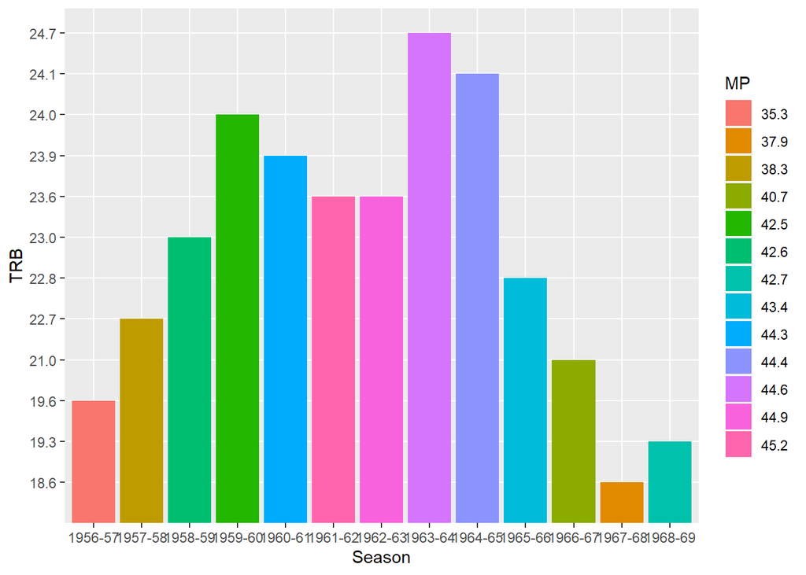

Wykres słupkowy przedstawia ilość zbiórek w podziale na sezony, zaś kolor kolumn oznacza średnią ilość minut rozegranych w danym sezonie. Łatwo można zauważyć że Bill najwięcej piłek(24.7) zbierał w sezonie 1963-64 i grał wtedy średnio 44.6 minut na mecz.

### Earvin “Magic” Johnson

**Magic Johnson** (właśc. **Earvin Johnson Jr.** ur. 14 sierpnia 1959 w Lansing) – amerykański koszykarz, grający w drużynie Los Angeles Lakers w latach 80. i na początku 90. XX wieku. Po zdobyciu tytułów mistrzowskich w szkole średniej i w college’u, Johnson został wybrany z pierwszym numerem w drafcie NBA 1979 przez Los Angeles Lakers. W swym debiutanckim sezonie zdobył mistrzostwo i nagrodę najbardziej wartościowego gracza finałów NBA. W latach 80. zdobył kolejne cztery tytuły z Lakersami. Na sportową emeryturę odszedł nagle w 1991 po tym, jak ogłosił, że uległ zakażeniu wirusem HIV, ale powrócił w 1992 na mecz gwiazd, gdzie otrzymał nagrodę MVP. Po protestach niektórych zawodników ponownie zakończył karierę, by powrócić raz jeszcze w 1996 roku, w wieku 37 lat, rozgrywając 32 mecze w zespole Lakers i po raz trzeci i ostatni odejść od uprawiania zawodowego sportu. “Magic Johnson” (2022)

[figure not shown]

Magic Johnson

Table 6: Statystyki Magica Johnsona

| Season | Tm | G | MP | FG | FG% | 3P | 3P% | 2P | 2P% | FT | FT% | TRB | AST | PTS |
| --- | --- | --- | --- | --- | --- | --- | --- | --- | --- | --- | --- | --- | --- | --- |
| 1979-80 | LAL | 77 | 36.3 | 6.5 | .530 | 0.1 | .226 | 6.4 | .540 | 4.9 | .810 | 7.7 | 7.3 | 18.0 |
| 1980-81 | LAL | 37 | 37.1 | 8.4 | .532 | 0.1 | .176 | 8.4 | .542 | 4.6 | .760 | 8.6 | 8.6 | 21.6 |
| 1981-82 | LAL | 78 | 38.3 | 7.1 | .537 | 0.1 | .207 | 7.1 | .546 | 4.2 | .760 | 9.6 | 9.5 | 18.6 |
| 1982-83 | LAL | 79 | 36.8 | 6.5 | .548 | 0.0 | .000 | 6.5 | .560 | 3.8 | .800 | 8.6 | 10.5 | 16.8 |
| 1983-84 | LAL | 67 | 38.3 | 6.6 | .565 | 0.1 | .207 | 6.5 | .579 | 4.3 | .810 | 7.3 | 13.1 | 17.6 |
| 1984-85 | LAL | 77 | 36.1 | 6.5 | .561 | 0.1 | .189 | 6.5 | .577 | 5.1 | .843 | 6.2 | 12.6 | 18.3 |
| 1985-86 | LAL | 72 | 35.8 | 6.7 | .526 | 0.1 | .233 | 6.6 | .541 | 5.3 | .871 | 5.9 | 12.6 | 18.8 |
| 1986-87 | LAL | 80 | 36.3 | 8.5 | .522 | 0.1 | .205 | 8.4 | .532 | 6.7 | .848 | 6.3 | 12.2 | 23.9 |
| 1987-88 | LAL | 72 | 36.6 | 6.8 | .492 | 0.2 | .196 | 6.7 | .510 | 5.8 | .853 | 6.2 | 11.9 | 19.6 |
| 1988-89 | LAL | 77 | 37.5 | 7.5 | .509 | 0.8 | .314 | 6.8 | .548 | 6.7 | .911 | 7.9 | 12.8 | 22.5 |
| 1989-90 | LAL | 79 | 37.2 | 6.9 | .480 | 1.3 | .384 | 5.6 | .510 | 7.2 | .890 | 6.6 | 11.5 | 22.3 |
| 1990-91 | LAL | 79 | 37.1 | 5.9 | .477 | 1.0 | .320 | 4.9 | .532 | 6.6 | .906 | 7.0 | 12.5 | 19.4 |
| 1995-96 | LAL | 32 | 29.9 | 4.3 | .466 | 0.7 | .379 | 3.6 | .487 | 5.4 | .856 | 5.7 | 6.9 | 14.6 |

W tabeli Table 6 są umieszczone statystyki z podziałem na sezony. Wiersz zaznaczony na kolor zielony pokazuje sezon, w którym Earvin zdobył mistrzostwo ligi jednocześnie będąc MVP finałów.

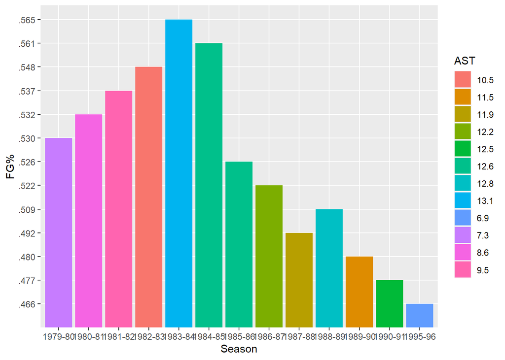

## LeBron “King” James

**LeBron James** (ur. 30 grudnia 1984 w Akron, Ohio) – amerykański koszykarz znany z gry przede wszystkim w Cleveland Cavaliers w NBA. Jego nominalna pozycja to niski skrzydłowy, lecz warunki fizyczne Jamesa (dynamika, waga) oraz jego wyjątkowy przegląd pola sprawiają, że trudno jest przyporządkować mu pozycję według tradycyjnych kryteriów, gdyż w praktyce może on pełnić zarówno rolę rozgrywającego, jak i silnego skrzydłowego. Otrzymał nagrodę najbardziej wartościowego gracza (MVP) ligi w sezonach 2008/2009, 2009/2010, 2011/2012, 2012/2013 oraz MVP finałów – 2012, 2013,2016 i 2020. “LeBron James” (2022)

[figure not shown]

LeBron James

Table 7: Statystyki LeBrona Jamesa

| Season | Tm | Pos | G | MP | FG | FGA | FG% | 3P% | 2P% | FT% | TRB | AST | PTS |
| --- | --- | --- | --- | --- | --- | --- | --- | --- | --- | --- | --- | --- | --- |
| 2003-04 | CLE | SG | 79 | 39.5 | 7.9 | 18.9 | .417 | .290 | .438 | .754 | 5.5 | 5.9 | 20.9 |
| 2004-05 | CLE | SF | 80 | 42.4 | 9.9 | 21.1 | .472 | .351 | .499 | .750 | 7.4 | 7.2 | 27.2 |
| 2005-06 | CLE | SF | 79 | 42.5 | 11.1 | 23.1 | .480 | .335 | .518 | .738 | 7.0 | 6.6 | 31.4 |
| 2006-07 | CLE | SF | 78 | 40.9 | 9.9 | 20.8 | .476 | .319 | .513 | .698 | 6.7 | 6.0 | 27.3 |
| 2007-08 | CLE | SF | 75 | 40.4 | 10.6 | 21.9 | .484 | .315 | .531 | .712 | 7.9 | 7.2 | 30.0 |
| 2008-09 | CLE | SF | 81 | 37.7 | 9.7 | 19.9 | .489 | .344 | .535 | .780 | 7.6 | 7.2 | 28.4 |
| 2009-10 | CLE | SF | 76 | 39.0 | 10.1 | 20.1 | .503 | .333 | .560 | .767 | 7.3 | 8.6 | 29.7 |
| 2010-11 | MIA | SF | 79 | 38.8 | 9.6 | 18.8 | .510 | .330 | .552 | .759 | 7.5 | 7.0 | 26.7 |
| 2011-12 | MIA | SF | 62 | 37.5 | 10.0 | 18.9 | .531 | .362 | .556 | .771 | 7.9 | 6.2 | 27.1 |
| 2012-13 | MIA | PF | 76 | 37.9 | 10.1 | 17.8 | .565 | .406 | .602 | .753 | 8.0 | 7.3 | 26.8 |
| 2013-14 | MIA | PF | 77 | 37.7 | 10.0 | 17.6 | .567 | .379 | .622 | .750 | 6.9 | 6.3 | 27.1 |
| 2014-15 | CLE | SF | 69 | 36.1 | 9.0 | 18.5 | .488 | .354 | .536 | .710 | 6.0 | 7.4 | 25.3 |
| 2015-16 | CLE | SF | 76 | 35.6 | 9.7 | 18.6 | .520 | .309 | .573 | .731 | 7.4 | 6.8 | 25.3 |
| 2016-17 | CLE | SF | 74 | 37.8 | 9.9 | 18.2 | .548 | .363 | .611 | .674 | 8.6 | 8.7 | 26.4 |
| 2017-18 | CLE | PF | 82 | 36.9 | 10.5 | 19.3 | .542 | .367 | .603 | .731 | 8.6 | 9.1 | 27.5 |
| 2018-19 | LAL | SF | 55 | 35.2 | 10.1 | 19.9 | .510 | .339 | .582 | .665 | 8.5 | 8.3 | 27.4 |
| 2019-20 | LAL | PG | 67 | 34.6 | 9.6 | 19.4 | .493 | .348 | .564 | .693 | 7.8 | 10.2 | 25.3 |
| 2020-21 | LAL | PG | 45 | 33.4 | 9.4 | 18.3 | .513 | .365 | .591 | .698 | 7.7 | 7.8 | 25.0 |
| 2021-22 | LAL | PF | 56 | 37.2 | 11.4 | 21.8 | .524 | .359 | .620 | .756 | 8.2 | 6.2 | 30.3 |

W tabeli Table 7 są umieszczone statystyki z podziałem na sezony. Wiersz zaznaczony kolorem zielonym oznacza najlepszy sezon Jamesa pod względem zdobytych punktów.

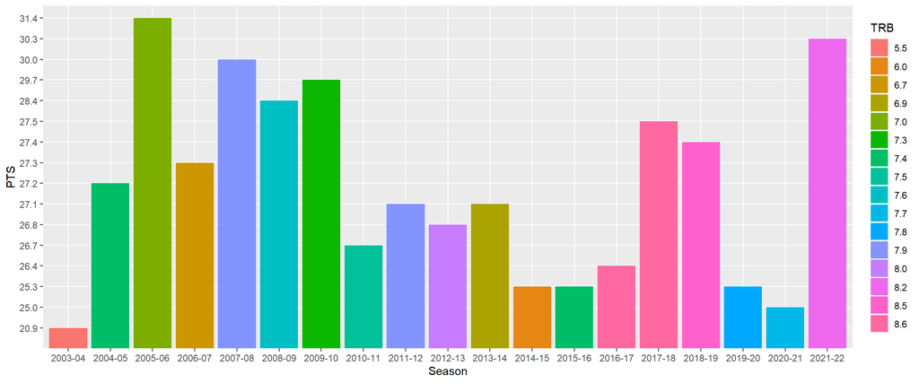

Wykres słupkowy przedstawia ilość punktów w podziale na sezony, zaś kolor kolumn oznacza średnią ilość zbiórek zdobytych w danym sezonie. “King James” jest drugim zawodnikiem w historii NBA pod względem zdobytych punktów. Mówiąc konkretniej ma ich aktualnie na koncie **37 870** co daje **27.1** pkt/mecz przy skuteczności **50.5%** (stan na 03.01.2023r.)

## References

“2021-22 NBA Season Summary.” n.d. https://www.basketball-reference.com/leagues/NBA_2022.html.

“Bill Russell.” 2022. https://pl.wikipedia.org/w/index.php?title=Bill_Russell&oldid=67799219.

“LeBron James.” 2022. https://pl.wikipedia.org/w/index.php?title=LeBron_James&oldid=69130086.

“Magic Johnson.” 2022. https://pl.wikipedia.org/w/index.php?title=Magic_Johnson&oldid=69172524.

“National Basketball Association.” 2022. https://pl.wikipedia.org/w/index.php?title=National_Basketball_Association&oldid=68093792.